# Ejercicio integrador

Temas del 1 al 4

Autor/a

Sustituya por su nombre

# Paquetes y datos

```r
library(survival)    # contiene la base pbc
library(dplyr)
library(ggplot2)
library(rstatix)     # pruebas en formato tidy
library(effectsize)  # tamaños del efecto con IC 95 % (cárguelo después de rstatix)
library(ggstatsplot)
```

Usaremos la base `pbc` (*Primary Biliary Cholangitis*, Mayo Clinic, 1974–1984). Incluye 418 pacientes con cirrosis biliar primaria. Nos interesan estas variables:

- `stage`: estadio histológico de la enfermedad (1 a 4).
- `albumin`: albúmina sérica (g/dL).
- `bili`: bilirrubina sérica (mg/dL).
- `edema`: 0 = sin edema, 0.5 = edema sin diuréticos o resuelto, 1 = edema pese a diuréticos.
- `status`: 0 = censurado, 1 = trasplante, 2 = muerte.

Preparamos los datos: convertimos a factores y eliminamos los pacientes sin estadio.

```r
datos <- pbc |>
  filter(!is.na(stage)) |>
  mutate(
    estadio = factor(stage),
    edema   = factor(edema, levels = c(0, 0.5, 1),
                     labels = c("Sin edema", "Edema leve", "Edema grave")),
    muerte  = factor(if_else(status == 2, "Sí", "No"), levels = c("Sí", "No"))
  )

datos |> count(estadio)
```

```
  estadio   n
1       1  21
2       2  92
3       3 155
4       4 144
```

```r
glimpse(datos)
```

```
Rows: 412
Columns: 22
$ id       <int> 1, 2, 3, 4, 5, 6, 7, 8, 9, 10, 11, 12, 13, 14, 15, 16, 17, 18…
$ time     <int> 400, 4500, 1012, 1925, 1504, 2503, 1832, 2466, 2400, 51, 3762…
$ status   <int> 2, 0, 2, 2, 1, 2, 0, 2, 2, 2, 2, 2, 0, 2, 2, 0, 2, 2, 0, 2, 0…
$ trt      <int> 1, 1, 1, 1, 2, 2, 2, 2, 1, 2, 2, 2, 2, 2, 1, 2, 2, 1, 1, 2, 2…
$ age      <dbl> 58.76523, 56.44627, 70.07255, 54.74059, 38.10541, 66.25873, 5…
$ sex      <fct> f, f, m, f, f, f, f, f, f, f, f, f, f, m, f, f, f, f, f, f, m…
$ ascites  <int> 1, 0, 0, 0, 0, 0, 0, 0, 0, 1, 0, 0, 0, 1, 0, 0, 0, 0, 0, 0, 0…
$ hepato   <int> 1, 1, 0, 1, 1, 1, 1, 0, 0, 0, 1, 0, 0, 1, 0, 0, 1, 1, 1, 1, 1…
$ spiders  <int> 1, 1, 0, 1, 1, 0, 0, 0, 1, 1, 1, 1, 0, 0, 0, 0, 0, 1, 0, 0, 1…
$ edema    <fct> Edema grave, Sin edema, Edema leve, Edema leve, Sin edema, Si…
$ bili     <dbl> 14.5, 1.1, 1.4, 1.8, 3.4, 0.8, 1.0, 0.3, 3.2, 12.6, 1.4, 3.6,…
$ chol     <int> 261, 302, 176, 244, 279, 248, 322, 280, 562, 200, 259, 236, 2…
$ albumin  <dbl> 2.60, 4.14, 3.48, 2.54, 3.53, 3.98, 4.09, 4.00, 3.08, 2.74, 4…
$ copper   <int> 156, 54, 210, 64, 143, 50, 52, 52, 79, 140, 46, 94, 40, 43, 1…
$ alk.phos <dbl> 1718.0, 7394.8, 516.0, 6121.8, 671.0, 944.0, 824.0, 4651.2, 2…
$ ast      <dbl> 137.95, 113.52, 96.10, 60.63, 113.15, 93.00, 60.45, 28.38, 14…
$ trig     <int> 172, 88, 55, 92, 72, 63, 213, 189, 88, 143, 79, 95, 130, NA, …
$ platelet <int> 190, 221, 151, 183, 136, NA, 204, 373, 251, 302, 258, 71, 244…
$ protime  <dbl> 12.2, 10.6, 12.0, 10.3, 10.9, 11.0, 9.7, 11.0, 11.0, 11.5, 12…
$ stage    <int> 4, 3, 4, 4, 3, 3, 3, 3, 2, 4, 4, 4, 3, 4, 3, 3, 4, 4, 3, 4, 4…
$ estadio  <fct> 4, 3, 4, 4, 3, 3, 3, 3, 2, 4, 4, 4, 3, 4, 3, 3, 4, 4, 3, 4, 4…
$ muerte   <fct> Sí, No, Sí, Sí, No, Sí, No, Sí, Sí, Sí, Sí, Sí, No, Sí, Sí, N…
```

Puede crear una EDA por estadio con:

```r
DataExplorer::create_report(datos, y = "estadio")
```

# Caso 1 · Albúmina y estadio (ruta paramétrica)

## Paso 1. Pregunta e hipótesis

> **¿La albúmina sérica difiere entre los estadios histológicos de la enfermedad?**
- H₀: la albúmina media es igual en los cuatro estadios.
- H₁: al menos un estadio tiene una media distinta.

## Paso 2. Gráfico y descriptivos

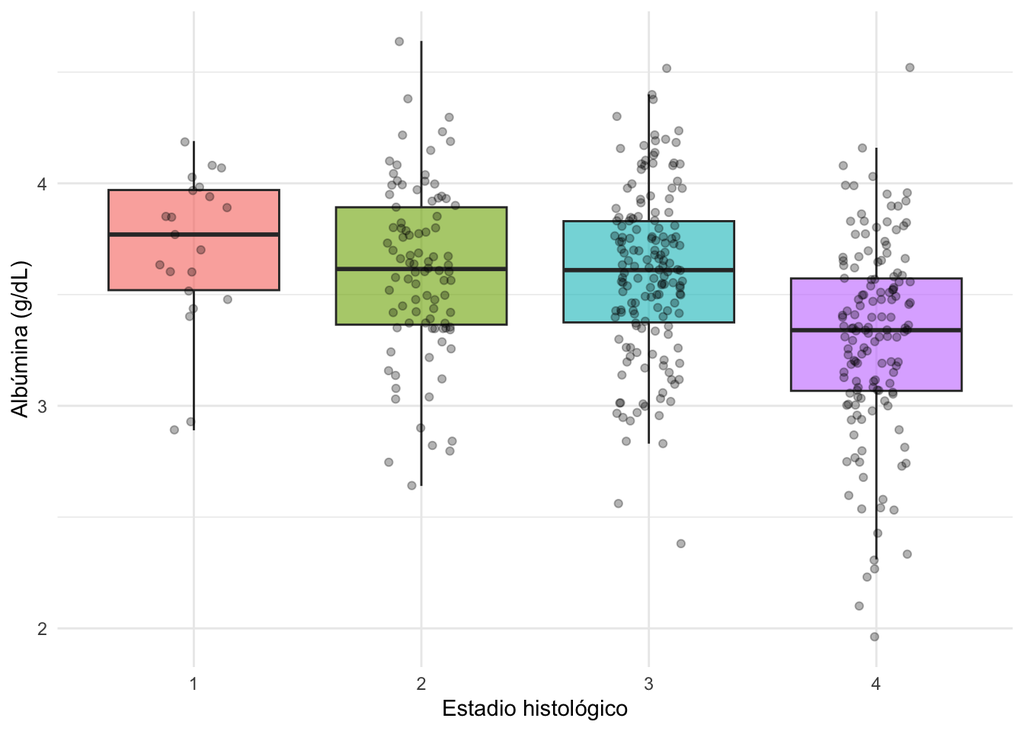

```r
ggplot(datos, aes(x = estadio, y = albumin, fill = estadio)) +
  geom_boxplot(alpha = 0.6, outlier.shape = NA) +
  geom_jitter(width = 0.15, alpha = 0.3) +
  labs(x = "Estadio histológico", y = "Albúmina (g/dL)") +
  theme_minimal() +
  theme(legend.position = "none")
```

La opción `type = "mean_ci"` nos da la media de cada grupo con su IC 95 %:

```r
datos |>
  group_by(estadio) |>
  get_summary_stats(albumin, type = "mean_ci")
```

```
# A tibble: 4 × 5
  estadio variable     n  mean    ci
  <fct>   <fct>    <dbl> <dbl> <dbl>
1 1       albumin     21  3.70 0.159
2 2       albumin     92  3.61 0.08
3 3       albumin    155  3.59 0.06
4 4       albumin    144  3.30 0.072
```

¿qué tendencia observa en la gráfica?

## Paso 3. Supuestos y selección de la prueba

Instale:

```r
install.packages('ggrain')
```

y luego

```r
library(ggrain)
```

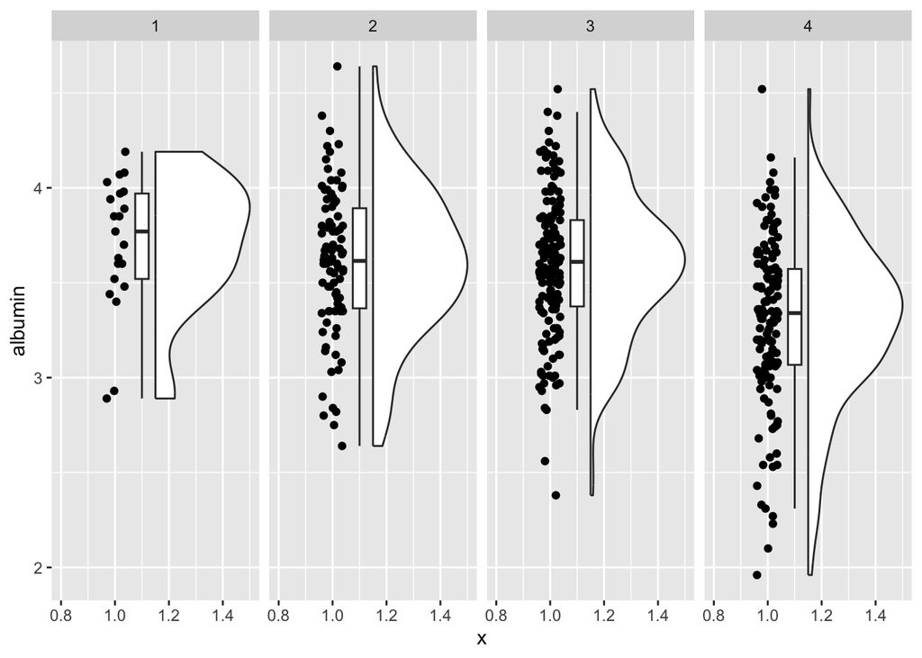

```r
datos |> ggplot(mapping = aes(x= 1, y = albumin))+
  geom_rain()+
  facet_grid(~estadio)
```

```r
# Normalidad dentro de cada grupo
datos |>
  group_by(estadio) |>
  shapiro_test(albumin)
```

```
# A tibble: 4 × 4
  estadio variable statistic      p
  <fct>   <chr>        <dbl>  <dbl>
1 1       albumin      0.915 0.0706
2 2       albumin      0.992 0.830
3 3       albumin      0.992 0.522
4 4       albumin      0.981 0.0410
```

```r
# Homogeneidad de varianzas
datos |> levene_test(albumin ~ estadio)
```

```
# A tibble: 1 × 4
    df1   df2 statistic     p
  <int> <int>     <dbl> <dbl>
1     3   408     0.837 0.474
```

**Decisión:** si la normalidad es razonable (revise también el gráfico) y Levene no es significativa → **ANOVA** + **Tukey**. Si las varianzas difieren → **ANOVA de Welch** + **Games-Howell**.

Suponga que los datos siguen distrbución normal en todos los grupos.

## Paso 4. Prueba global

```r
datos |> anova_test(albumin ~ estadio)
```

```
ANOVA Table (type II tests)

   Effect DFn DFd     F        p p<.05  ges
1 estadio   3 408 18.59 2.54e-11     * 0.12
```

Alternativa si las varianzas no son iguales:

```r
datos |> welch_anova_test(albumin ~ estadio)
```

```
# A tibble: 1 × 7
  .y.         n statistic   DFn   DFd             p method
* <chr>   <int>     <dbl> <dbl> <dbl>         <dbl> <chr>
1 albumin   412      17.1     3  89.4 0.00000000739 Welch ANOVA
```

```r
# De rstatix no asume homegenidad de varianzas
```

## Paso 5. Tamaño del efecto con IC 95 %

```r
modelo <- aov(albumin ~ estadio, data = datos)
eta <- effectsize::eta_squared(modelo, alternative = "two.sided")
eta
```

```
# Effect Size for ANOVA

Parameter | Eta2 |       95% CI
-------------------------------
estadio   | 0.12 | [0.06, 0.18]
```

```r
interpret_eta_squared(eta$Eta2)   # pequeño, mediano o grande
```

```
[1] "medium"
(Rules: field2013)
```

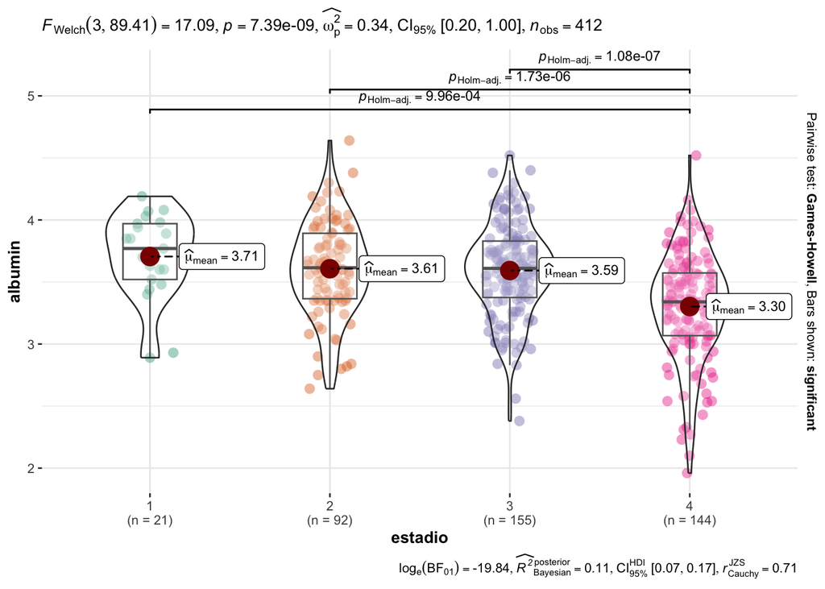

```r
datos |>
  ggbetweenstats(x = estadio, y = albumin, type = "p")
```

## Paso 6. Prueba pos hoc

```r
datos |> tukey_hsd(albumin ~ estadio)
```

```
# A tibble: 6 × 9
  term    group1 group2 null.value estimate conf.low conf.high         p.adj
* <chr>   <chr>  <chr>       <dbl>    <dbl>    <dbl>     <dbl>         <dbl>
1 estadio 1      2               0  -0.0982   -0.347     0.151 0.74
2 estadio 1      3               0  -0.113    -0.352     0.127 0.617
3 estadio 1      4               0  -0.403    -0.643    -0.162 0.000115
4 estadio 2      3               0  -0.0147   -0.150     0.121 0.992
5 estadio 2      4               0  -0.305    -0.442    -0.167 0.000000124
6 estadio 3      4               0  -0.290    -0.409    -0.171 0.00000000527
# ℹ 1 more variable: p.adj.signif <chr>
```

Cada fila muestra la **diferencia de medias** (`estimate`), su **IC 95 %** (`conf.low`, `conf.high`) y el valor *p* ajustado. Si las varianzas no fueran iguales, use:

```r
datos |> games_howell_test(albumin ~ estadio)
```

```
# A tibble: 6 × 8
  .y.     group1 group2 estimate conf.low conf.high       p.adj p.adj.signif
* <chr>   <chr>  <chr>     <dbl>    <dbl>     <dbl>       <dbl> <chr>
1 albumin 1      2       -0.0982   -0.331     0.135 0.668       ns
2 albumin 1      3       -0.113    -0.337     0.112 0.524       ns
3 albumin 1      4       -0.403    -0.632    -0.173 0.000249    ***
4 albumin 2      3       -0.0147   -0.145     0.115 0.991       ns
5 albumin 2      4       -0.305    -0.445    -0.164 0.000000346 ****
6 albumin 3      4       -0.290    -0.412    -0.168 0.000000018 ****
```

## Conclusión (plantilla)

> La albúmina sérica difirió entre estadios (ANOVA, F = *, p =* ), con un tamaño del efecto ___ (η² = *, IC 95 %* a *). La prueba de Tukey mostró que* difiere de ___ (diferencia = ___ g/dL, IC 95 % ___ a ___).

# Caso 2 · Bilirrubina y estadio (ruta no paramétrica)

## Paso 1. Pregunta e hipótesis

> **¿La bilirrubina sérica difiere entre los estadios histológicos?**
- H₀: la distribución de bilirrubina es igual en los cuatro estadios.
- H₁: al menos un estadio tiene una distribución distinta.

## Paso 2. Gráfico y descriptivos

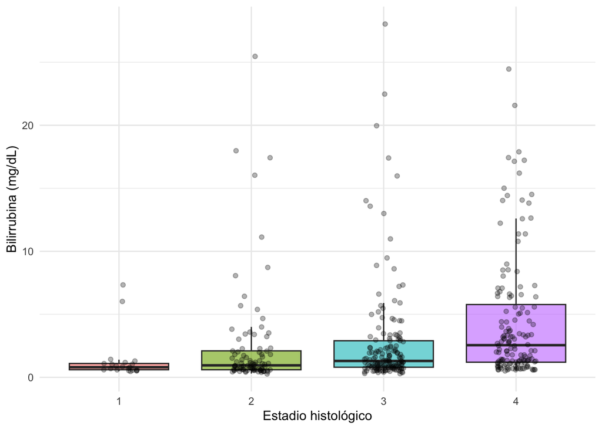

```r
ggplot(datos, aes(x = estadio, y = bili, fill = estadio)) +
  geom_boxplot(alpha = 0.6, outlier.shape = NA) +
  geom_jitter(width = 0.15, alpha = 0.3) +
  labs(x = "Estadio histológico", y = "Bilirrubina (mg/dL)") +
  theme_minimal() +
  theme(legend.position = "none")
```

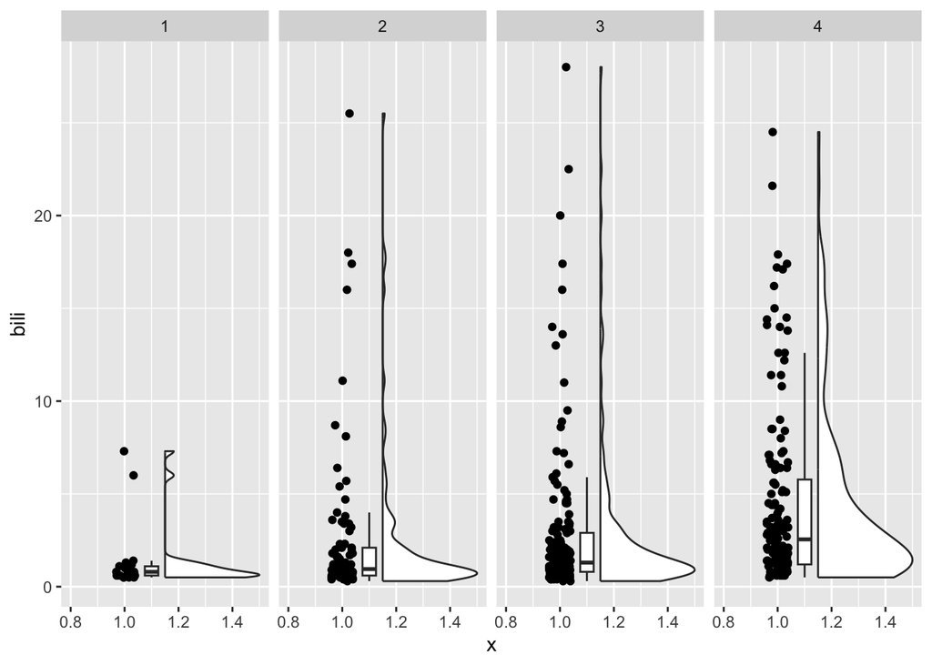

```r
datos |> ggplot(mapping = aes(x= 1, y = bili))+
  geom_rain()+
  facet_grid(~estadio)
```

```r
datos |>
  group_by(estadio) |>
  get_summary_stats(bili, type = "median_iqr")
```

```
# A tibble: 4 × 5
  estadio variable     n median   iqr
  <fct>   <fct>    <dbl>  <dbl> <dbl>
1 1       bili        21   0.8   0.5
2 2       bili        92   0.95  1.5
3 3       bili       155   1.3   2.1
4 4       bili       144   2.55  4.58
```

cómo es la forma de la distribución? ¿Qué medida de tendencia central es mejor aquí?

## Paso 3. Supuestos y selección de la prueba

```r
datos |>
  group_by(estadio) |>
  shapiro_test(bili)
```

```
# A tibble: 4 × 4
  estadio variable statistic        p
  <fct>   <chr>        <dbl>    <dbl>
1 1       bili         0.487 1.55e- 7
2 2       bili         0.506 4.63e-16
3 3       bili         0.560 1.10e-19
4 4       bili         0.755 3.15e-14
```

**Decisión:** la bilirrubina es muy asimétrica y no es normal → **Kruskal-Wallis** + **Dunn**.

## Paso 4. Prueba global

```r
datos |> kruskal_test(bili ~ estadio)
```

```
# A tibble: 1 × 6
  .y.       n statistic    df        p method
* <chr> <int>     <dbl> <int>    <dbl> <chr>
1 bili    412      46.6     3 4.15e-10 Kruskal-Wallis
```

## Paso 5. Tamaño del efecto con IC 95 %

```r
epsilon <- rank_epsilon_squared(bili ~ estadio, data = datos, alternative = "two.sided")
epsilon
```

```
Epsilon2 (rank) |       95% CI
------------------------------
0.11            | [0.06, 0.18]
```

```r
interpret_epsilon_squared(epsilon$rank_epsilon_squared)
```

```
[1] "medium"
(Rules: field2013)
```

## Paso 6. Prueba pos hoc

```r
datos |> dunn_test(bili ~ estadio, p.adjust.method = "holm")
```

```
# A tibble: 6 × 9
  .y.   group1 group2    n1    n2 statistic            p      p.adj p.adj.signif
* <chr> <chr>  <chr>  <int> <int>     <dbl>        <dbl>      <dbl> <chr>
1 bili  1      2         21    92      1.43 0.152           1.52e-1 ns
2 bili  1      3         21   155      2.66 0.00773         2.32e-2 *
3 bili  1      4         21   144      4.74 0.00000214      1.07e-5 ****
4 bili  2      3         92   155      2.07 0.0383          7.65e-2 ns
5 bili  2      4         92   144      5.70 0.0000000122    7.32e-8 ****
6 bili  3      4        155   144      4.21 0.0000252       1.01e-4 ***
```

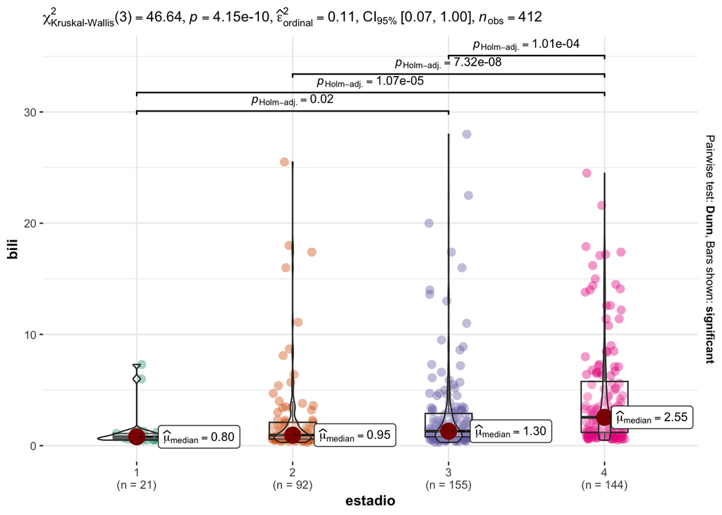

```r
datos |>
  ggbetweenstats(x = estadio, y = bili, type = 'np')
```

## Conclusión (plantilla)

> La bilirrubina difirió entre estadios (Kruskal-Wallis, H = *, gl =* , p = *; ε² =* , IC 95 % ___ a *). La prueba de Dunn con ajuste de Holm mostró diferencias entre* .

# Caso 3 · Edema y muerte (variables categóricas)

## Paso 1. Pregunta e hipótesis

> **¿La proporción de pacientes que fallecen depende del grado de edema?**
- H₀: edema y muerte son independientes.
- H₁: edema y muerte están asociados.

## Paso 2. Gráfico y tabla

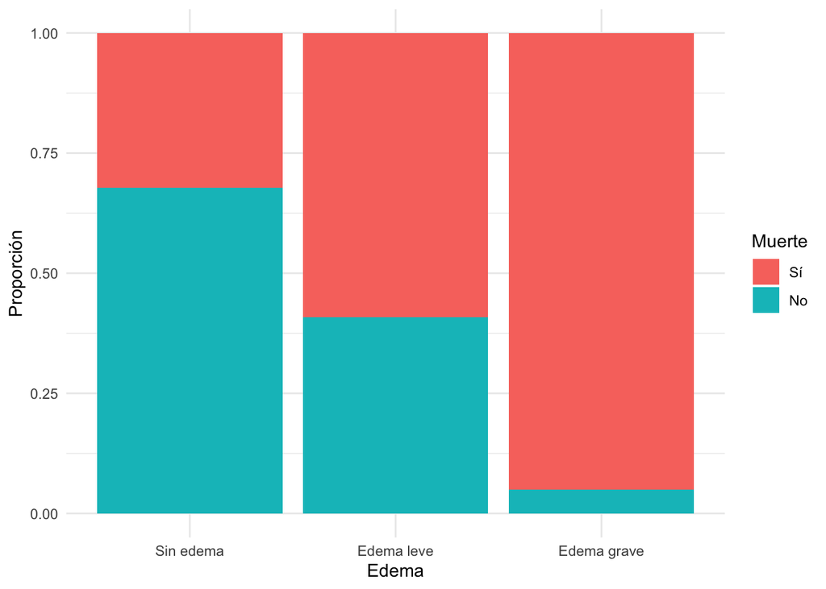

```r
ggplot(datos, aes(x = edema, fill = muerte)) +
  geom_bar(position = "fill") +
  labs(x = "Edema", y = "Proporción", fill = "Muerte") +
  theme_minimal()
```

```r
tabla <- table(datos$edema, datos$muerte)
tabla
```

```
               Sí  No
  Sin edema   112 236
  Edema leve   26  18
  Edema grave  19   1
```

## Paso 3. Supuestos y selección de la prueba

```r
chisq.test(tabla)$expected
```

```
                      Sí        No
  Sin edema   132.611650 215.38835
  Edema leve   16.766990  27.23301
  Edema grave   7.621359  12.37864
```

**Decisión:** si todas las frecuencias esperadas son ≥ 5 → **χ²**. Si no → prueba exacta de Fisher (`fisher_test(tabla)`).

## Paso 4. Prueba global

```r
chisq_test(tabla)
```

```
# A tibble: 1 × 6
      n statistic             p    df method          p.signif
* <int>     <dbl>         <dbl> <int> <chr>           <chr>
1   412      40.8 0.00000000136     2 Chi-square test ****
```

## Paso 5. Tamaño del efecto con IC 95 %

```r
v <- cramers_v(tabla, alternative = "two.sided")
v
```

```
Cramer's V (adj.) |       95% CI
--------------------------------
0.31              | [0.20, 0.40]
```

```r
interpret_cramers_v(v$Cramers_v_adjusted)
```

```
[1] "large"
(Rules: funder2019)
```

## Paso 6. Prueba pos hoc

Comparamos la proporción de muertes entre cada par de grupos de edema:

```r
pairwise_prop_test(tabla, p.adjust.method = "holm")
```

```
# A tibble: 3 × 5
  group1     group2                 p       p.adj p.adj.signif
* <chr>      <chr>              <dbl>       <dbl> <chr>
1 Sin edema  Edema leve  0.000798     0.0016      **
2 Sin edema  Edema grave 0.0000000462 0.000000139 ****
3 Edema leve Edema grave 0.00881      0.00881     **
```

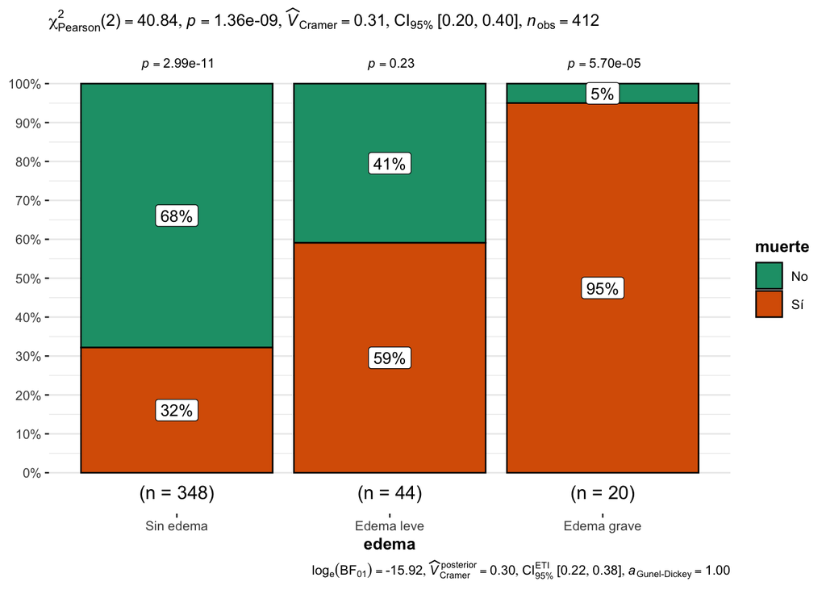

```r
datos |>
  ggbarstats(x = muerte, y = edema)
```

## Conclusión (plantilla)

> La muerte se asoció al grado de edema (χ² = *, gl =* , p = *; V de Cramér =* , IC 95 % ___ a *). Las comparaciones por pares mostraron que* .

# Caso 4 · Expresión génica y comparaciones múltiples (FDR)

En genómica no se hace **una** prueba, se hacen **miles** (una por gen). Si usa α = 0.05 en cada una, esperará muchos falsos positivos solo por azar. En este caso aprenderá a controlarlos con la **tasa de falsos descubrimientos** (*False Discovery Rate*, FDR).

Usaremos datos **simulados**, lo que tiene una ventaja: sabemos qué genes cambian de verdad y podemos contar cuántos errores comete cada método.

## Paso 1. Pregunta e hipótesis

> **¿Qué genes cambian su expresión entre controles sanos, pacientes con artritis reumatoide (AR) y pacientes con T-LGLL?**

Para **cada gen**:

- H₀: la expresión media es igual en los tres grupos.
- H₁: al menos un grupo tiene una media distinta.

## Simulación de los datos

- 2000 genes y 30 muestras (10 por grupo).
- La expresión está en escala log₂, con media 8 y DE 1.
- **Solo los primeros 200 genes** están realmente sobreexpresados en T-LGLL (+1.5 unidades log₂). Los otros 1800 no cambian.

```r
library(tidyr)

set.seed(2026)
n_genes <- 2000
grupos  <- rep(c("Control", "AR", "T-LGLL"), each = 10)

# Matriz de expresión: filas = genes, columnas = muestras
expresion <- matrix(rnorm(n_genes * 30, mean = 8, sd = 1), nrow = n_genes)
rownames(expresion) <- paste0("gen_", 1:n_genes)

# Los genes 1 a 200 aumentan su expresión en T-LGLL
expresion[1:200, grupos == "T-LGLL"] <- expresion[1:200, grupos == "T-LGLL"] + 1.5

genes_reales <- paste0("gen_", 1:200)
```

Pasamos la matriz a formato largo (una fila por gen y muestra), como en el tema 1:

```r
expr_larga <- as.data.frame(expresion) |>
  mutate(gen = rownames(expresion)) |>
  pivot_longer(-gen, names_to = "muestra", values_to = "expresion") |>
  mutate(grupo = factor(rep(grupos, n_genes),
                        levels = c("Control", "AR", "T-LGLL")))

head(expr_larga)
```

```
# A tibble: 6 × 4
  gen   muestra expresion grupo
  <chr> <chr>       <dbl> <fct>
1 gen_1 V1           8.52 Control
2 gen_1 V2           8.20 Control
3 gen_1 V3           9.23 Control
4 gen_1 V4           8.11 Control
5 gen_1 V5           8.29 Control
6 gen_1 V6           7.58 Control
```

## Paso 2. Gráfico de un gen

Antes de analizar 2000 genes, observe dos de ellos: uno que sí cambia (`gen_1`) y uno que no (`gen_1500`).

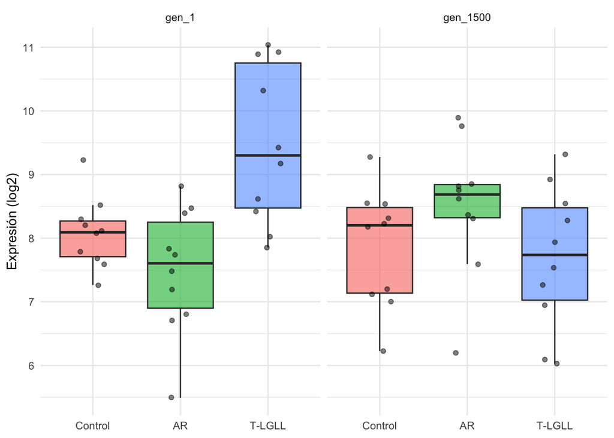

```r
expr_larga |>
  filter(gen %in% c("gen_1", "gen_1500")) |>
  ggplot(aes(x = grupo, y = expresion, fill = grupo)) +
  geom_boxplot(alpha = 0.6, outlier.shape = NA) +
  geom_jitter(width = 0.15, alpha = 0.5) +
  facet_wrap(~ gen) +
  labs(x = NULL, y = "Expresión (log2)") +
  theme_minimal() +
  theme(legend.position = "none")
```

## Paso 3. Selección de la prueba

Los datos de expresión en escala log₂ se aproximan a la normal y simulamos varianzas iguales, así que usamos **ANOVA de una vía** en cada gen.

**Nota**

En estudios reales de RNA-seq o microarreglos se usan paquetes especializados (`limma`, `DESeq2`, `edgeR`). Hacen pruebas más potentes, pero la lógica del FDR es exactamente la misma.

## Paso 4. Una prueba por gen

`group_by(gen)` repite la prueba en cada gen. Guardamos también el **log₂ fold change** (T-LGLL vs. Control), que en genómica se usa como tamaño del efecto:

```r
resultados <- expr_larga |>
  group_by(gen) |>
  summarise(
    p      = oneway.test(expresion ~ grupo, var.equal = TRUE)$p.value,
    log2FC = mean(expresion[grupo == "T-LGLL"]) - mean(expresion[grupo == "Control"])
  )

head(resultados)
```

```
# A tibble: 6 × 3
  gen             p log2FC
  <chr>       <dbl>  <dbl>
1 gen_1    0.000338  1.39
2 gen_10   0.00135   1.68
3 gen_100  0.274     0.736
4 gen_1000 0.0794   -0.357
5 gen_1001 0.262    -0.495
6 gen_1002 0.261     0.461
```

El histograma de valores *p* es un diagnóstico clásico en genómica. Si ningún gen cambiara, sería plano, porque bajo H₀ los valores *p* son uniformes. El pico cerca de 0 corresponde a los genes que sí cambian.

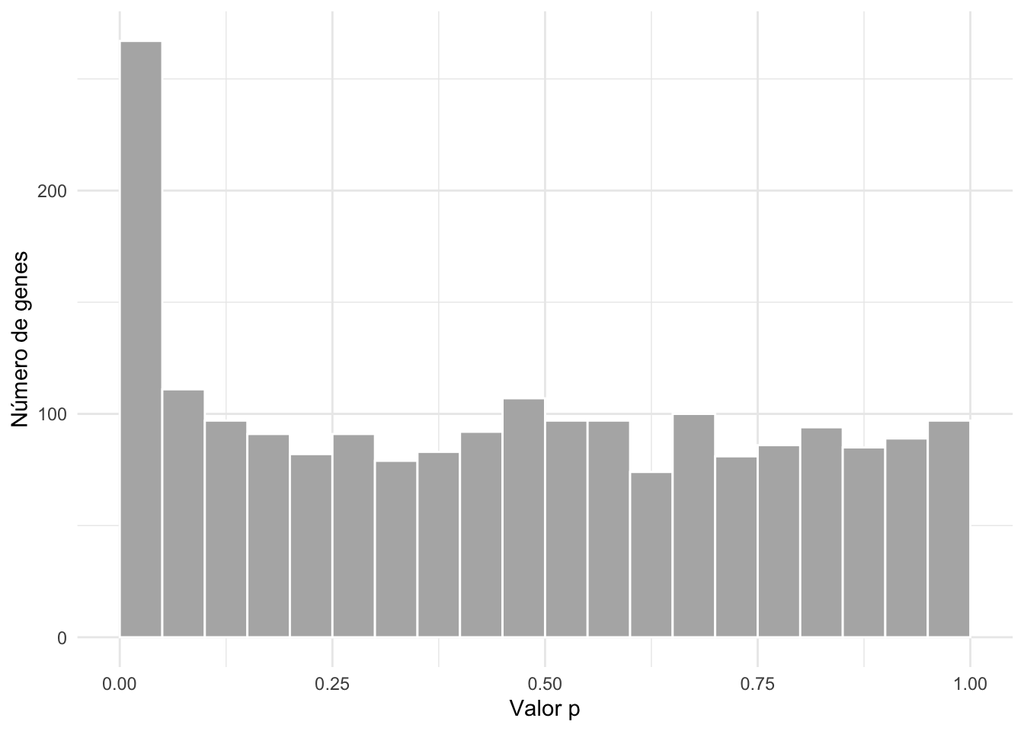

```r
ggplot(resultados, aes(x = p)) +
  geom_histogram(breaks = seq(0, 1, 0.05), fill = "grey70", color = "white") +
  labs(x = "Valor p", y = "Número de genes") +
  theme_minimal()
```

### El problema: ¿cuántos genes son “significativos”?

Ajustamos los valores *p* con dos métodos:

- **Bonferroni**: controla la probabilidad de cometer **al menos un** falso positivo (FWER). Es muy estricto.
- **Benjamini-Hochberg (FDR)**: controla la **proporción** de falsos positivos **entre los genes que declara significativos**. Con FDR < 0.05, se espera que alrededor del 5 % de sus “descubrimientos” sean falsos.

```r
resultados <- resultados |>
  mutate(
    p_bonf = p.adjust(p, method = "bonferroni"),
    p_fdr  = p.adjust(p, method = "BH"),
    real   = gen %in% genes_reales
  )
```

Como conocemos la verdad, podemos contar aciertos y errores:

```r
resultados |>
  group_by(real) |>
  summarise(
    sin_correccion = sum(p < 0.05),
    bonferroni     = sum(p_bonf < 0.05),
    fdr            = sum(p_fdr < 0.05)
  )
```

```
# A tibble: 2 × 4
  real  sin_correccion bonferroni   fdr
  <lgl>          <int>      <int> <int>
1 FALSE             85          0     5
2 TRUE             182         23   103
```

La fila `real = FALSE` son los **falsos positivos** (genes que no cambian pero salieron significativos) y la fila `real = TRUE` son los **verdaderos positivos** (de 200 posibles).

**Preguntas para usted:**

- Sin corrección, ¿cuántos falsos positivos obtuvo? Compárelo con lo esperado: 1800 × 0.05 = 90.
- ¿Cuántos genes reales pierde Bonferroni?
- ¿Qué proporción de los genes que declara el FDR son falsos? ¿Se acerca al 5 %?

### Gráfico de volcán

Es la figura típica de un análisis de expresión diferencial: tamaño del efecto (log₂FC) en el eje x y evidencia (−log₁₀ *p*) en el eje y.

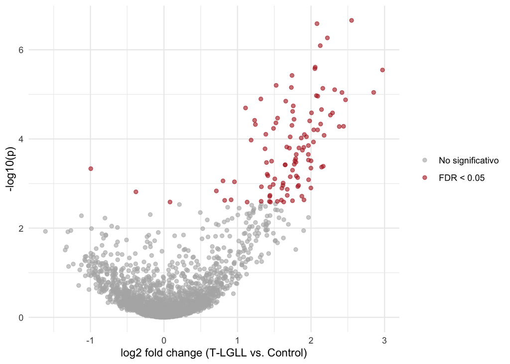

```r
ggplot(resultados, aes(x = log2FC, y = -log10(p), color = p_fdr < 0.05)) +
  geom_point(alpha = 0.6) +
  scale_color_manual(values = c("grey70", "firebrick"),
                     labels = c("No significativo", "FDR < 0.05")) +
  labs(x = "log2 fold change (T-LGLL vs. Control)", y = "-log10(p)", color = NULL) +
  theme_minimal()
```

## Paso 5. Tamaño del efecto con IC 95 % (un gen)

Tome el gen con el menor valor *p* ajustado y calcule η² con su IC, igual que en el Caso 1:

```r
top_gen <- resultados |> arrange(p_fdr) |> slice(1) |> pull(gen)
top_gen
```

```
[1] "gen_198"
```

```r
modelo_gen <- aov(expresion ~ grupo, data = filter(expr_larga, gen == top_gen))
effectsize::eta_squared(modelo_gen, alternative = "two.sided")
```

```
# Effect Size for ANOVA

Parameter | Eta2 |       95% CI
-------------------------------
grupo     | 0.68 | [0.44, 0.80]
```

## Paso 6. Prueba pos hoc en los genes significativos

La prueba pos hoc se aplica **solo a los genes que pasaron el FDR**. Así se responde qué grupos difieren en cada gen:

```r
genes_sig <- resultados |> filter(p_fdr < 0.05) |> pull(gen)

posthoc <- expr_larga |>
  filter(gen %in% genes_sig) |>
  group_by(gen) |>
  tukey_hsd(expresion ~ grupo)

# ¿Qué comparación explica las diferencias?
posthoc |>
  filter(p.adj < 0.05) |>
  count(group1, group2)
```

```
# A tibble: 3 × 3
  group1  group2     n
  <chr>   <chr>  <int>
1 AR      T-LGLL   103
2 Control AR         5
3 Control T-LGLL   104
```

**Pregunta para usted:** ¿qué comparaciones aparecen con más frecuencia? ¿Coincide con cómo se simularon los datos?

## Conclusión (plantilla)

> De 2000 genes evaluados, ___ tuvieron *p* < 0.05 sin corrección, ___ tras Bonferroni y ___ con FDR < 0.05 (Benjamini-Hochberg). En la mayoría de los genes significativos, la prueba de Tukey mostró que la diferencia se debe a ___ vs. *, con log₂FC de* .

# Ejercicios

Resuelva cada pregunta siguiendo los **seis pasos**. Justifique por escrito la prueba que eligió.

1. ¿El conteo de plaquetas (`platelet`) difiere entre los estadios histológicos?
2. ¿El colesterol sérico (`chol`) difiere según el grado de edema?
3. ¿La presencia de hepatomegalia (`hepato`) se asocia al estadio histológico?
4. **Reflexión:** en los tres casos resueltos el valor *p* fue muy pequeño. Compare los tamaños del efecto y sus IC 95 %: ¿cuál asociación es más fuerte? ¿Qué información le da el IC que no le da el valor *p*?
5. **Genómica:** repita el Caso 4 cambiando el efecto simulado de `+ 1.5` a `+ 0.8`. ¿Qué pasa con el número de genes detectados por Bonferroni y por FDR? ¿Y con la proporción de falsos positivos del FDR?